# Course Notes

## Jupyter Lab Overview

Start Jupyter Lab

- client server architecture
- browser connects to server
- kernels execute commands
- different kernels available
- terminals, text editor, notebook

You can arrange panels as you like them.

```python
pwd
```

```
'/home/jet08013/GitHub/Carpentries/2020-01-13/notes'
```

[figure not shown]

Notebook blends text (markdown) and code (python, in our case)

- click in a box to activate it
- **esc** gives you access to the notebook commands (menu, etc)
- **m** makes a book markdown, **y** makes it code -- or use the menu at the top

## Simple Markdown

- for lists
- lists
- list items with hypen

*emphasis* **bold**

[links](http://www.nytimes.com)

## Latex

For those who know TeX, the notebook can render math:

$$\sum_{i=1}^{\infty}\frac{1}{n^2} = \frac{\pi^2}{6}$$

# Python

Python is an interpreted language and the blocks of the notebook can be used as a calculator (a fancy one!)

### Variables

```python
name = "Jeremy"
age = 60
probability = .35
```

```python
print(name, age, probability)
```

```
Jeremy 60 0.35
```

```python
print(name, 'is', age,'years old with probability',probability)
```

```
Jeremy is 60 years old with probability 0.35
```

Variables must be created before being used, by having a value assigned to them.

```python
temperature
```

[output not shown]

```python
temperature=50
```

```python
temperature*2
```

```
100
```

```python
print("the temperature is:", temperature)
```

```
the temperature is: 50
```

```python
full_name = "Jeremy Teitelbaum"
```

```python
full_name[3]
```

```
'e'
```

**In python, indexing starts from zero!!!**

```python
full_name[0]
```

```
'J'
```

```python
len(full_name)
```

```
17
```

### Types

- strings
- integers
- floats
- lists

```python
a=123
b='123'
```

```python
a[1]
```

```
---------------------------------------------------------------------------
TypeError                                 Traceback (most recent call last)
<ipython-input-26-8bc71255a22e> in <module>
----> 1 a[1]

TypeError: 'int' object is not subscriptable
```

```python
b[1]
```

```
'2'
```

```python
L = ['jeremy', 'kendra', 'parkisheet']
```

```python
L[0]
```

```
'jeremy'
```

### Slicing

```python
full_name[1:3]
```

```
'er'
```

```python
full_name[5:]
```

```
'y Teitelbaum'
```

```python
full_name[:5]
```

```
'Jerem'
```

```python
full_name[3:5:3]
```

```
'e'
```

```python
full_name[:-1]
```

```
'Jeremy Teitelbau'
```

```python
full_name[-1]
```

```
'm'
```

```python
full_name[-1::-1]
```

```
'muabletieT ymereJ'
```

```python
L = ['a','b','c','d']
```

```python
L[1:3]
```

```
['b', 'c']
```

```python
L[-1]
```

```
'd'
```

```python
L[::2]
```

```
['a', 'c']
```

```python
magic_word = "thanos_must_die"
```

- What command will determine how many letters are in the `magic_word`?
- How would you print the fifth through eighth letters of the magic word (inclusive)?

```python
print(magic_word[4:8])
print(magic_word[7:])
print(magic_word[:3])
print(magic_word[:])
print(magic_word[2:-3])
print(magic_word[-3:2:-1])
print(magic_word[0:100])
```

```
os_m
must_die
tha
thanos_must_die
anos_must_
d_tsum_son
thanos_must_die
```

## Types

In python, every variable has a type, but the language figures out the appropriate type by itself.

The most important types are:

- strings
- integers
- floating point

```python
x="this is a string"
a=137.50
b=12e-1
c=133
```

```python
print(a)
```

```
137.5
```

```python
print(b)
```

```
1.2
```

```python
print(c)
```

```
133
```

```python
type(a)
```

```
float
```

```python
type(b)
```

```
float
```

```python
type(c)
```

```
int
```

```python
type(x)
```

```
str
```

## Operations on numbers and strings

They're what you'd expect, with some caveats.

```python
x=3.5
y=x/5
z=x*22.4
w=x*1e-1
print("x=",x,"y=",y,"z=",z,"w=",w)
```

```
x= 3.5 y= 0.7 z= 78.39999999999999 w= 0.35000000000000003
```

String addition is concatenation.

```python
x="Jeremy"+"Teitelbaum"
```

```python
print(x)
```

```
JeremyTeitelbaum
```

Mixing floats and integers is ok (you get a float) but mixing strings and numbers is a problem.

```python
1+3.5
```

```
4.5
```

```python
"Jeremy"+3
```

```
---------------------------------------------------------------------------
TypeError                                 Traceback (most recent call last)
<ipython-input-51-8b1195841f62> in <module>
----> 1 "Jeremy"+3

TypeError: can only concatenate str (not "int") to str
```

You can convert floats or ints to strings and then combine them:

```python
"Jeremy Teitelbaum is "+60+" years old"
```

```
---------------------------------------------------------------------------
TypeError                                 Traceback (most recent call last)
<ipython-input-55-1d48ca8ed8ea> in <module>
----> 1 "Jeremy Teitelbaum is "+60+" years old"

TypeError: can only concatenate str (not "int") to str
```

```python
"Jeremy Teitelbaum is "+str(60)+" years old"
```

```
'Jeremy Teitelbaum is 60 years old'
```

```python
3*"a"
```

```
'aaa'
```

```python
type("hello")
```

```
str
```

```python
type(60)
```

```
int
```

```python
type(3.6)
```

```
float
```

```python
len("Jeremy")
```

```
6
```

```python
len(3.5)
```

```
---------------------------------------------------------------------------
TypeError                                 Traceback (most recent call last)
<ipython-input-63-5c30567bf151> in <module>
----> 1 len(3.5)

TypeError: object of type 'float' has no len()
```

### Operations on lists

```python
L = ['jeremy','kendra', 'pariksheet','dyanna']
```

```python
S = ['mouse', 'cat']
```

```python
L+S
```

```
['jeremy', 'kendra', 'pariksheet', 'dyanna', 'mouse', 'cat']
```

```python
sorted(L)
```

```
['dyanna', 'jeremy', 'kendra', 'pariksheet']
```

```python
['a']*3
```

```
['a', 'a', 'a']
```

```python
L = L + ['x']
print(L)
```

[output not shown]

### strings to lists and back

```python
list('abcdefg')
```

```
['a', 'b', 'c', 'd', 'e', 'f', 'g']
```

```python
''.join(['a','b','c'])
```

```
'abc'
```

## Dictionaries

```python
f = {}
f['jeremy']=15
f['kendra']=33
f['marshmallow']=100
f['french_fries']='hello'
```

```python
f['jeremy']
```

```
15
```

```python
f['french_fries']
```

```
'hello'
```

```python
f[0]
```

```
---------------------------------------------------------------------------
KeyError                                  Traceback (most recent call last)
<ipython-input-286-d8711d29ed7d> in <module>
----> 1 f[0]

KeyError: 0
```

```python
f.keys()
```

```
dict_keys(['jeremy', 'kendra', 'marshmallow', 'french_fries'])
```

```python
f.values()
```

```
dict_values([15, 33, 100, 'hello'])
```

```python
a = dict(name=['jeremy','kendra','pariksheet'],gender=['m','f','m'])
```

```python
a
```

```
{'name': ['jeremy', 'kendra', 'pariksheet'], 'gender': ['m', 'f', 'm']}
```

# Comments

```python
# this goes in a code cell, but doesn't get executed
```

# f(x,y,z) returns a value

- len
- int, str, float
- print
- max
- min
- round
- **help** - function or shift-Tab

```python
round(3.12131,3)
```

```
3.121
```

```python
max('hello')
```

```
'o'
```

```python
min("hello")
```

```
'e'
```

```python
round("hello")
```

```
---------------------------------------------------------------------------
TypeError                                 Traceback (most recent call last)
<ipython-input-73-06fcaad98a98> in <module>
----> 1 round("hello")

TypeError: type str doesn't define __round__ method
```

```python
1/2
```

```
0.5
```

```python
result = 60
```

```python
report = "the result is "+str(result)
```

```python
print(report)
```

```
the result is 60
```

```python
#help(type)
```

```python
help(round)
```

```
Help on built-in function round in module builtins:

round(number, ndigits=None)
    Round a number to a given precision in decimal digits.

    The return value is an integer if ndigits is omitted or None.  Otherwise
    the return value has the same type as the number.  ndigits may be negative.
```

```python
round(123,-2)
```

```
100
```

```python
round(1351,-1)
```

```
1350
```

```python
#help()
```

```python
report = "Now is the time to flee'
```

```
  File "<ipython-input-467-51897dfb7c04>", line 1
    report = "Now is the time to flee'
                                      ^
SyntaxError: EOL while scanning string literal
```

```python
1/0
```

```
---------------------------------------------------------------------------
ZeroDivisionError                         Traceback (most recent call last)
<ipython-input-468-9e1622b385b6> in <module>
----> 1 1/0

ZeroDivisionError: division by zero
```

```python
y = 15-23
x = y+8
z= 3/x
```

```
---------------------------------------------------------------------------
ZeroDivisionError                         Traceback (most recent call last)
<ipython-input-469-23b9d1a37b92> in <module>
      1 y = 15-23
      2 x = y+8
----> 3 z= 3/x

ZeroDivisionError: division by zero
```

```python
max()
```

```
---------------------------------------------------------------------------
TypeError                                 Traceback (most recent call last)
<ipython-input-470-f870ea12a3fc> in <module>
----> 1 max()

TypeError: max expected 1 arguments, got 0
```

```python
min()
```

```
---------------------------------------------------------------------------
TypeError                                 Traceback (most recent call last)
<ipython-input-471-9c9b7bdfea4e> in <module>
----> 1 min()

TypeError: min expected 1 arguments, got 0
```

## Libraries

### Python is a very simple language

- There are only 33 "keywords" in the python language

  ```
  False, class, finally, is, return, None, continue, for, lambda, try, True, def, from, nonlocal, while, and, del, global, not, with, as, elif, if, or, yield, assert, else, import, pass, break, except, in, raise
  ```

All of the interesting capabilities of the language come from extensions to the basic language; these extensions are called "libraries" or "modules".

The language also includes about 100 built-in functions. The functions

```
int, len, print, str, type, max, min
```

are built-in library. The built-in functions are very primitive.

To get access to more interesting functions, you need to

```
import
```

them by importing the library that defines them. Many interesting capabilities are added by the [standard library](https://docs.python.org/3/library/)

### Two important libraries

- numpy
- pandas

```python
import numpy
import pandas
```

```python
print('pi is ',numpy.pi)
```

```
pi is  3.141592653589793
```

```python
print('e is ',numpy.exp(1))
```

```
e is  2.718281828459045
```

Notice that we refer to the function exp, for example, by first naming the library it came from.

```python
exp(1)
```

[output not shown]

```python
math.exp(1)
```

```
2.718281828459045
```

You can get help on a library/module using the help command.

The import command also allows you to adopt abbreviations.

```python
import numpy as np
```

```python
np.exp(1)
```

```
2.718281828459045
```

```python
from numpy import exp
```

```python
exp(1)
```

```
2.718281828459045
```

```python
import numpy.random
```

```python
numpy.random.choice([1,2,3,4,5])
```

```
3
```

```python
np.random.choice(list('ACTTGCTTGAC'))
```

```
'T'
```

```python
import math
import random
bases = "ACTTGCTTGAC"
n_bases = len(bases)
idx = np.random.randint(n_bases)
print("random base", bases[idx], "base index", idx)
```

```
random base C base index 10
```

- Data frames are "like" spreadsheets
  - Columns
  - Index
- manipulation is through "methods"

```python
import numpy.random as rnd
```

```python
rnd.randint(20)
```

```
11
```

## Numpy arrays

```python
a=np.arange(0,10,.1)
```

```python
numpy.cos(a)
```

```
array([ 1.        ,  0.99500417,  0.98006658,  0.95533649,  0.92106099,
        0.87758256,  0.82533561,  0.76484219,  0.69670671,  0.62160997,
        0.54030231,  0.45359612,  0.36235775,  0.26749883,  0.16996714,
        0.0707372 , -0.02919952, -0.12884449, -0.22720209, -0.32328957,
       -0.41614684, -0.5048461 , -0.58850112, -0.66627602, -0.73739372,
       -0.80114362, -0.85688875, -0.90407214, -0.94222234, -0.97095817,
       -0.9899925 , -0.99913515, -0.99829478, -0.98747977, -0.96679819,
       -0.93645669, -0.89675842, -0.84810003, -0.79096771, -0.7259323 ,
       -0.65364362, -0.57482395, -0.49026082, -0.40079917, -0.30733287,
       -0.2107958 , -0.11215253, -0.01238866,  0.08749898,  0.18651237,
        0.28366219,  0.37797774,  0.46851667,  0.55437434,  0.63469288,
        0.70866977,  0.77556588,  0.83471278,  0.88551952,  0.92747843,
        0.96017029,  0.98326844,  0.9965421 ,  0.99985864,  0.99318492,
        0.97658763,  0.95023259,  0.91438315,  0.86939749,  0.8157251 ,
        0.75390225,  0.68454667,  0.60835131,  0.52607752,  0.43854733,
        0.34663532,  0.25125984,  0.15337386,  0.05395542, -0.04600213,
       -0.14550003, -0.24354415, -0.33915486, -0.43137684, -0.51928865,
       -0.6020119 , -0.67872005, -0.74864665, -0.81109301, -0.86543521,
       -0.91113026, -0.9477216 , -0.97484362, -0.99222533, -0.99969304,
       -0.99717216, -0.98468786, -0.96236488, -0.93042627, -0.88919115])
```

```python
3*a
```

```
array([ 0. ,  0.3,  0.6,  0.9,  1.2,  1.5,  1.8,  2.1,  2.4,  2.7,  3. ,
        3.3,  3.6,  3.9,  4.2,  4.5,  4.8,  5.1,  5.4,  5.7,  6. ,  6.3,
        6.6,  6.9,  7.2,  7.5,  7.8,  8.1,  8.4,  8.7,  9. ,  9.3,  9.6,
        9.9, 10.2, 10.5, 10.8, 11.1, 11.4, 11.7, 12. , 12.3, 12.6, 12.9,
       13.2, 13.5, 13.8, 14.1, 14.4, 14.7, 15. , 15.3, 15.6, 15.9, 16.2,
       16.5, 16.8, 17.1, 17.4, 17.7, 18. , 18.3, 18.6, 18.9, 19.2, 19.5,
       19.8, 20.1, 20.4, 20.7, 21. , 21.3, 21.6, 21.9, 22.2, 22.5, 22.8,
       23.1, 23.4, 23.7, 24. , 24.3, 24.6, 24.9, 25.2, 25.5, 25.8, 26.1,
       26.4, 26.7, 27. , 27.3, 27.6, 27.9, 28.2, 28.5, 28.8, 29.1, 29.4,
       29.7])
```

```python
a*a
```

```
array([0.000e+00, 1.000e-02, 4.000e-02, 9.000e-02, 1.600e-01, 2.500e-01,
       3.600e-01, 4.900e-01, 6.400e-01, 8.100e-01, 1.000e+00, 1.210e+00,
       1.440e+00, 1.690e+00, 1.960e+00, 2.250e+00, 2.560e+00, 2.890e+00,
       3.240e+00, 3.610e+00, 4.000e+00, 4.410e+00, 4.840e+00, 5.290e+00,
       5.760e+00, 6.250e+00, 6.760e+00, 7.290e+00, 7.840e+00, 8.410e+00,
       9.000e+00, 9.610e+00, 1.024e+01, 1.089e+01, 1.156e+01, 1.225e+01,
       1.296e+01, 1.369e+01, 1.444e+01, 1.521e+01, 1.600e+01, 1.681e+01,
       1.764e+01, 1.849e+01, 1.936e+01, 2.025e+01, 2.116e+01, 2.209e+01,
       2.304e+01, 2.401e+01, 2.500e+01, 2.601e+01, 2.704e+01, 2.809e+01,
       2.916e+01, 3.025e+01, 3.136e+01, 3.249e+01, 3.364e+01, 3.481e+01,
       3.600e+01, 3.721e+01, 3.844e+01, 3.969e+01, 4.096e+01, 4.225e+01,
       4.356e+01, 4.489e+01, 4.624e+01, 4.761e+01, 4.900e+01, 5.041e+01,
       5.184e+01, 5.329e+01, 5.476e+01, 5.625e+01, 5.776e+01, 5.929e+01,
       6.084e+01, 6.241e+01, 6.400e+01, 6.561e+01, 6.724e+01, 6.889e+01,
       7.056e+01, 7.225e+01, 7.396e+01, 7.569e+01, 7.744e+01, 7.921e+01,
       8.100e+01, 8.281e+01, 8.464e+01, 8.649e+01, 8.836e+01, 9.025e+01,
       9.216e+01, 9.409e+01, 9.604e+01, 9.801e+01])
```

```python
a+numpy.exp(a)
```

```
array([1.00000000e+00, 1.20517092e+00, 1.42140276e+00, 1.64985881e+00,
       1.89182470e+00, 2.14872127e+00, 2.42211880e+00, 2.71375271e+00,
       3.02554093e+00, 3.35960311e+00, 3.71828183e+00, 4.10416602e+00,
       4.52011692e+00, 4.96929667e+00, 5.45519997e+00, 5.98168907e+00,
       6.55303242e+00, 7.17394739e+00, 7.84964746e+00, 8.58589444e+00,
       9.38905610e+00, 1.02661699e+01, 1.12250135e+01, 1.22741825e+01,
       1.34231764e+01, 1.46824940e+01, 1.60637380e+01, 1.75797317e+01,
       1.92446468e+01, 2.10741454e+01, 2.30855369e+01, 2.52979513e+01,
       2.77325302e+01, 3.04126389e+01, 3.33641000e+01, 3.66154520e+01,
       4.01982344e+01, 4.41473044e+01, 4.85011845e+01, 5.33024491e+01,
       5.85981500e+01, 6.44402876e+01, 7.08863310e+01, 7.79997937e+01,
       8.58508687e+01, 9.45171313e+01, 1.04084316e+02, 1.14647172e+02,
       1.26310418e+02, 1.39189780e+02, 1.53413159e+02, 1.69121907e+02,
       1.86472242e+02, 2.05636810e+02, 2.26806416e+02, 2.50191932e+02,
       2.76026407e+02, 3.04567401e+02, 3.36099560e+02, 3.70937468e+02,
       4.09428793e+02, 4.51957770e+02, 4.98949041e+02, 5.50871910e+02,
       6.08245038e+02, 6.71641633e+02, 7.41695189e+02, 8.19105825e+02,
       9.04647292e+02, 9.99174716e+02, 1.10363316e+03, 1.21906707e+03,
       1.34663076e+03, 1.48759993e+03, 1.64338443e+03, 1.81554241e+03,
       2.00579590e+03, 2.21604799e+03, 2.44840198e+03, 2.70518233e+03,
       2.98895799e+03, 3.30256808e+03, 3.64915031e+03, 4.03217239e+03,
       4.45546675e+03, 4.92326884e+03, 5.44025959e+03, 6.01161222e+03,
       6.64304401e+03, 7.34087354e+03, 8.11208393e+03, 8.96439270e+03,
       9.90632906e+03, 1.09473192e+04, 1.20977807e+04, 1.33692268e+04,
       1.47743816e+04, 1.63273072e+04, 1.80435449e+04, 1.99402704e+04])
```

## DataFrames and Pandas

```python
import pandas as pd
```

### simple dataframes and dictionaries

```python
df = pd.DataFrame.from_dict(a)
```

```python
df
```

|  | name | gender |
| --- | --- | --- |
| 0 | jeremy | m |
| 1 | kendra | f |
| 2 | pariksheet | m |

```python
data = pd.read_csv('../gapminder_data.csv')
```

```python
data.columns
```

```
Index(['country', 'year', 'pop', 'continent', 'lifeExp', 'gdpPercap'], dtype='object')
```

```python
data.head()
```

|  | country | year | pop | continent | lifeExp | gdpPercap |
| --- | --- | --- | --- | --- | --- | --- |
| 0 | Afghanistan | 1952 | 8425333.0 | Asia | 28.801 | 779.445314 |
| 1 | Afghanistan | 1957 | 9240934.0 | Asia | 30.332 | 820.853030 |
| 2 | Afghanistan | 1962 | 10267083.0 | Asia | 31.997 | 853.100710 |
| 3 | Afghanistan | 1967 | 11537966.0 | Asia | 34.020 | 836.197138 |
| 4 | Afghanistan | 1972 | 13079460.0 | Asia | 36.088 | 739.981106 |

```python
data = pd.read_csv('../gapminder_data.csv', index_col='country')
```

```python
data.columns
```

```
Index(['year', 'pop', 'continent', 'lifeExp', 'gdpPercap'], dtype='object')
```

```python
data.info()
```

```
<class 'pandas.core.frame.DataFrame'>
Index: 1704 entries, Afghanistan to Zimbabwe
Data columns (total 5 columns):
year         1704 non-null int64
pop          1704 non-null float64
continent    1704 non-null object
lifeExp      1704 non-null float64
gdpPercap    1704 non-null float64
dtypes: float64(3), int64(1), object(1)
memory usage: 79.9+ KB
```

## selecting elements from dataframes

#### columns

```python
data['pop']
```

```
country
Afghanistan     8425333.0
Afghanistan     9240934.0
Afghanistan    10267083.0
Afghanistan    11537966.0
Afghanistan    13079460.0
                  ...
Zimbabwe        9216418.0
Zimbabwe       10704340.0
Zimbabwe       11404948.0
Zimbabwe       11926563.0
Zimbabwe       12311143.0
Name: pop, Length: 1704, dtype: float64
```

```python
data[['year','pop']]
```

| country | year | pop |
| --- | --- | --- |
| Afghanistan | 1952 | 8425333.0 |
| Afghanistan | 1957 | 9240934.0 |
| Afghanistan | 1962 | 10267083.0 |
| Afghanistan | 1967 | 11537966.0 |
| Afghanistan | 1972 | 13079460.0 |
| ... | ... | ... |
| Zimbabwe | 1987 | 9216418.0 |
| Zimbabwe | 1992 | 10704340.0 |
| Zimbabwe | 1997 | 11404948.0 |
| Zimbabwe | 2002 | 11926563.0 |
| Zimbabwe | 2007 | 12311143.0 |

1704 rows × 2 columns

## rows

### from the index

```python
data.loc['Afghanistan']
```

| country | year | pop | continent | lifeExp | gdpPercap |
| --- | --- | --- | --- | --- | --- |
| Afghanistan | 1952 | 8425333.0 | Asia | 28.801 | 779.445314 |
| Afghanistan | 1957 | 9240934.0 | Asia | 30.332 | 820.853030 |
| Afghanistan | 1962 | 10267083.0 | Asia | 31.997 | 853.100710 |
| Afghanistan | 1967 | 11537966.0 | Asia | 34.020 | 836.197138 |
| Afghanistan | 1972 | 13079460.0 | Asia | 36.088 | 739.981106 |
| Afghanistan | 1977 | 14880372.0 | Asia | 38.438 | 786.113360 |
| Afghanistan | 1982 | 12881816.0 | Asia | 39.854 | 978.011439 |
| Afghanistan | 1987 | 13867957.0 | Asia | 40.822 | 852.395945 |
| Afghanistan | 1992 | 16317921.0 | Asia | 41.674 | 649.341395 |
| Afghanistan | 1997 | 22227415.0 | Asia | 41.763 | 635.341351 |
| Afghanistan | 2002 | 25268405.0 | Asia | 42.129 | 726.734055 |
| Afghanistan | 2007 | 31889923.0 | Asia | 43.828 | 974.580338 |

## boolean selection on a column

```python
data['continent']=='Asia'
```

```
country
Afghanistan     True
Afghanistan     True
Afghanistan     True
Afghanistan     True
Afghanistan     True
               ...
Zimbabwe       False
Zimbabwe       False
Zimbabwe       False
Zimbabwe       False
Zimbabwe       False
Name: continent, Length: 1704, dtype: bool
```

```python
data[data['continent']=='Asia']
```

| country | year | pop | continent | lifeExp | gdpPercap |
| --- | --- | --- | --- | --- | --- |
| Afghanistan | 1952 | 8425333.0 | Asia | 28.801 | 779.445314 |
| Afghanistan | 1957 | 9240934.0 | Asia | 30.332 | 820.853030 |
| Afghanistan | 1962 | 10267083.0 | Asia | 31.997 | 853.100710 |
| Afghanistan | 1967 | 11537966.0 | Asia | 34.020 | 836.197138 |
| Afghanistan | 1972 | 13079460.0 | Asia | 36.088 | 739.981106 |
| ... | ... | ... | ... | ... | ... |
| Yemen Rep. | 1987 | 11219340.0 | Asia | 52.922 | 1971.741538 |
| Yemen Rep. | 1992 | 13367997.0 | Asia | 55.599 | 1879.496673 |
| Yemen Rep. | 1997 | 15826497.0 | Asia | 58.020 | 2117.484526 |
| Yemen Rep. | 2002 | 18701257.0 | Asia | 60.308 | 2234.820827 |
| Yemen Rep. | 2007 | 22211743.0 | Asia | 62.698 | 2280.769906 |

396 rows × 5 columns

```python
data[data['pop']>1e8]
```

| country | year | pop | continent | lifeExp | gdpPercap |
| --- | --- | --- | --- | --- | --- |
| Bangladesh | 1987 | 103764241.0 | Asia | 52.819 | 751.979403 |
| Bangladesh | 1992 | 113704579.0 | Asia | 56.018 | 837.810164 |
| Bangladesh | 1997 | 123315288.0 | Asia | 59.412 | 972.770035 |
| Bangladesh | 2002 | 135656790.0 | Asia | 62.013 | 1136.390430 |
| Bangladesh | 2007 | 150448339.0 | Asia | 64.062 | 1391.253792 |
| ... | ... | ... | ... | ... | ... |
| United States | 1987 | 242803533.0 | Americas | 75.020 | 29884.350410 |
| United States | 1992 | 256894189.0 | Americas | 76.090 | 32003.932240 |
| United States | 1997 | 272911760.0 | Americas | 76.810 | 35767.433030 |
| United States | 2002 | 287675526.0 | Americas | 77.310 | 39097.099550 |
| United States | 2007 | 301139947.0 | Americas | 78.242 | 42951.653090 |

77 rows × 5 columns

```python
data[data['lifeExp']<60]
```

| country | year | pop | continent | lifeExp | gdpPercap |
| --- | --- | --- | --- | --- | --- |
| Afghanistan | 1952 | 8425333.0 | Asia | 28.801 | 779.445314 |
| Afghanistan | 1957 | 9240934.0 | Asia | 30.332 | 820.853030 |
| Afghanistan | 1962 | 10267083.0 | Asia | 31.997 | 853.100710 |
| Afghanistan | 1967 | 11537966.0 | Asia | 34.020 | 836.197138 |
| Afghanistan | 1972 | 13079460.0 | Asia | 36.088 | 739.981106 |
| ... | ... | ... | ... | ... | ... |
| Zimbabwe | 1972 | 5861135.0 | Africa | 55.635 | 799.362176 |
| Zimbabwe | 1977 | 6642107.0 | Africa | 57.674 | 685.587682 |
| Zimbabwe | 1997 | 11404948.0 | Africa | 46.809 | 792.449960 |
| Zimbabwe | 2002 | 11926563.0 | Africa | 39.989 | 672.038623 |
| Zimbabwe | 2007 | 12311143.0 | Africa | 43.487 | 469.709298 |

827 rows × 5 columns

### numerical indexing

```python
data.iloc[33]
```

```
year               1997
pop          2.9072e+07
continent        Africa
lifeExp          69.152
gdpPercap        4797.3
Name: Algeria, dtype: object
```

```python
data.iloc[33,3]
```

```
69.152
```

### rows and columns

```python
data.loc['Afghanistan','pop']
```

```
country
Afghanistan     8425333.0
Afghanistan     9240934.0
Afghanistan    10267083.0
Afghanistan    11537966.0
Afghanistan    13079460.0
Afghanistan    14880372.0
Afghanistan    12881816.0
Afghanistan    13867957.0
Afghanistan    16317921.0
Afghanistan    22227415.0
Afghanistan    25268405.0
Afghanistan    31889923.0
Name: pop, dtype: float64
```

### statistics on numerical columns

```python
data.loc['Afghanistan','pop'].describe()
```

```
count    1.200000e+01
mean     1.582372e+07
std      7.114583e+06
min      8.425333e+06
25%      1.122025e+07
50%      1.347371e+07
75%      1.779529e+07
max      3.188992e+07
Name: pop, dtype: float64
```

## Grouping: optional

```python
s=data.groupby(['continent']).mean()
s.head()
```

| continent | year | pop | lifeExp | gdpPercap |
| --- | --- | --- | --- | --- |
| Africa | 1979.5 | 9.916003e+06 | 48.865330 | 2193.754578 |
| Americas | 1979.5 | 2.450479e+07 | 64.658737 | 7136.110356 |
| Asia | 1979.5 | 7.703872e+07 | 60.064903 | 7902.150428 |
| Europe | 1979.5 | 1.716976e+07 | 71.903686 | 14469.475533 |
| Oceania | 1979.5 | 8.874672e+06 | 74.326208 | 18621.609223 |

```python
averages_by_continent=data.groupby(['continent','year']).mean()
averages_by_continent.loc['Asia'].round()
```

| year | pop | lifeExp | gdpPercap |
| --- | --- | --- | --- |
| 1952 | 42283556.0 | 46.0 | 5195.0 |
| 1957 | 47356988.0 | 49.0 | 5788.0 |
| 1962 | 51404763.0 | 52.0 | 5729.0 |
| 1967 | 57747361.0 | 55.0 | 5971.0 |
| 1972 | 65180977.0 | 57.0 | 8187.0 |
| 1977 | 72257987.0 | 60.0 | 7791.0 |
| 1982 | 79095018.0 | 63.0 | 7434.0 |
| 1987 | 87006690.0 | 65.0 | 7608.0 |
| 1992 | 94948248.0 | 67.0 | 8640.0 |
| 1997 | 102523803.0 | 68.0 | 9834.0 |
| 2002 | 109145521.0 | 69.0 | 10174.0 |
| 2007 | 115513752.0 | 71.0 | 12473.0 |

## Pivot table

```python
lifeExp_over_time = pd.pivot_table(data,index='country',columns='year',values='lifeExp')
```

```python
lifeExp_over_time.loc['Afghanistan',:]
```

```
year
1952    28.801
1957    30.332
1962    31.997
1967    34.020
1972    36.088
1977    38.438
1982    39.854
1987    40.822
1992    41.674
1997    41.763
2002    42.129
2007    43.828
Name: Afghanistan, dtype: float64
```

```python
stats_over_time = pd.pivot_table(data,index=['continent','country'],columns='year',values=['lifeExp','gdpPercap','pop'])
stats_over_time_by_continent=stats_over_time.groupby('continent').mean()
```

```python
stats_over_time_by_continent['pop'].round(-3)
```

| year continent | 1952 | 1957 | 1962 | 1967 | 1972 | 1977 | 1982 | 1987 | 1992 | 1997 | 2002 | 2007 |
| --- | --- | --- | --- | --- | --- | --- | --- | --- | --- | --- | --- | --- |
| Africa | 4570000.0 | 5093000.0 | 5702000.0 | 6448000.0 | 7305000.0 | 8328000.0 | 9603000.0 | 11055000.0 | 12675000.0 | 14304000.0 | 16033000.0 | 17876000.0 |
| Americas | 13806000.0 | 15478000.0 | 17331000.0 | 19230000.0 | 21175000.0 | 23123000.0 | 25212000.0 | 27310000.0 | 29571000.0 | 31876000.0 | 33991000.0 | 35955000.0 |
| Asia | 42284000.0 | 47357000.0 | 51405000.0 | 57747000.0 | 65181000.0 | 72258000.0 | 79095000.0 | 87007000.0 | 94948000.0 | 102524000.0 | 109146000.0 | 115514000.0 |
| Europe | 13937000.0 | 14596000.0 | 15345000.0 | 16039000.0 | 16688000.0 | 17239000.0 | 17709000.0 | 18103000.0 | 18605000.0 | 18965000.0 | 19274000.0 | 19537000.0 |
| Oceania | 5343000.0 | 5971000.0 | 6642000.0 | 7300000.0 | 8053000.0 | 8620000.0 | 9197000.0 | 9787000.0 | 10460000.0 | 11121000.0 | 11727000.0 | 12275000.0 |

# plotting libraries:

```python
import matplotlib.pyplot as plt
plt.style.use('ggplot')
```

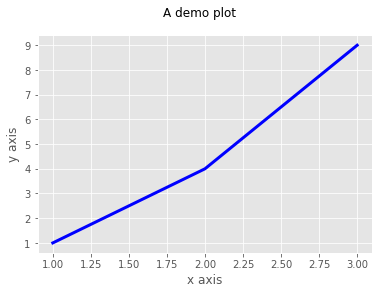

```python
plt.plot([1,2,3],[1,4,9],c='blue',linewidth=3,linestyle='solid')
plt.xlabel('x axis')
plt.ylabel('y axis')
plt.suptitle('A demo plot')
```

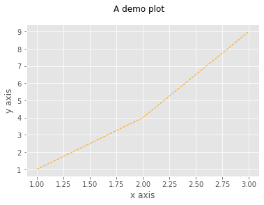

```python
plt.plot([1,2,3],[1,4,9],c='orange',linewidth=1,linestyle='dashed')
plt.xlabel('x axis')
plt.ylabel('y axis')
plt.suptitle('A demo plot')
```

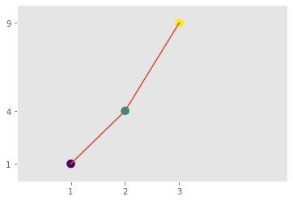

```python
plt.scatter([1,2,3],[1,4,9],c=[0,1,2],s=100)
plt.plot([1,2,3],[1,4,9])
plt.xticks([1,2,3])
plt.yticks([1,4,9])
plt.xlim(0,5)
plt.ylim(0,10)
plt.grid(False)
```

# Plotting from pandas

- the index is the x axis and the values in the column are plotted against that
- or you can specify x and y

```python
data.head()
```

| country | year | pop | continent | lifeExp | gdpPercap |
| --- | --- | --- | --- | --- | --- |
| Afghanistan | 1952 | 8425333.0 | Asia | 28.801 | 779.445314 |
| Afghanistan | 1957 | 9240934.0 | Asia | 30.332 | 820.853030 |
| Afghanistan | 1962 | 10267083.0 | Asia | 31.997 | 853.100710 |
| Afghanistan | 1967 | 11537966.0 | Asia | 34.020 | 836.197138 |
| Afghanistan | 1972 | 13079460.0 | Asia | 36.088 | 739.981106 |

```python
lifeExp_over_time.head()
```

| year country | 1952 | 1957 | 1962 | 1967 | 1972 | 1977 | 1982 | 1987 | 1992 | 1997 | 2002 | 2007 |
| --- | --- | --- | --- | --- | --- | --- | --- | --- | --- | --- | --- | --- |
| Afghanistan | 28.801 | 30.332 | 31.997 | 34.020 | 36.088 | 38.438 | 39.854 | 40.822 | 41.674 | 41.763 | 42.129 | 43.828 |
| Albania | 55.230 | 59.280 | 64.820 | 66.220 | 67.690 | 68.930 | 70.420 | 72.000 | 71.581 | 72.950 | 75.651 | 76.423 |
| Algeria | 43.077 | 45.685 | 48.303 | 51.407 | 54.518 | 58.014 | 61.368 | 65.799 | 67.744 | 69.152 | 70.994 | 72.301 |
| Angola | 30.015 | 31.999 | 34.000 | 35.985 | 37.928 | 39.483 | 39.942 | 39.906 | 40.647 | 40.963 | 41.003 | 42.731 |
| Argentina | 62.485 | 64.399 | 65.142 | 65.634 | 67.065 | 68.481 | 69.942 | 70.774 | 71.868 | 73.275 | 74.340 | 75.320 |

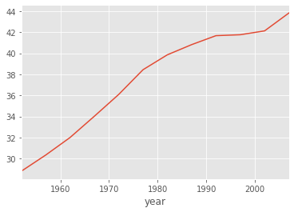

```python
lifeExp_over_time.T['Afghanistan'].plot()
```

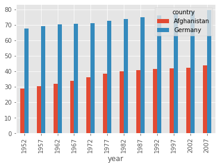

```python
transpose = lifeExp_over_time.T
transpose[['Afghanistan','Germany']].plot(kind='bar')
```

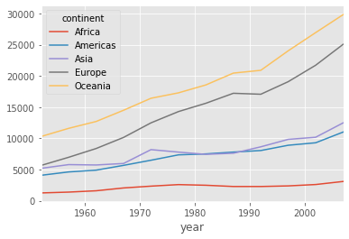

```python
_=stats_over_time.groupby('continent').mean()['gdpPercap'].T.plot()
```

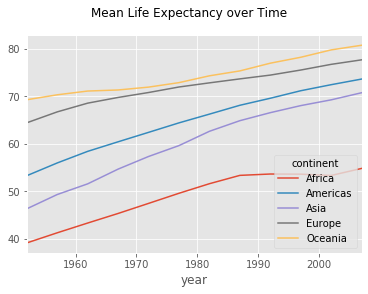

```python
stats_over_time.groupby('continent').mean()['lifeExp'].T.plot()
_=plt.suptitle('Mean Life Expectancy over Time')
```

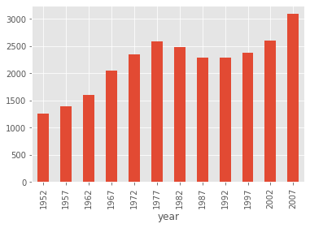

```python
_=stats_over_time['gdpPercap'].loc[['Africa']].mean().T.plot(kind='bar',legend=None)
```

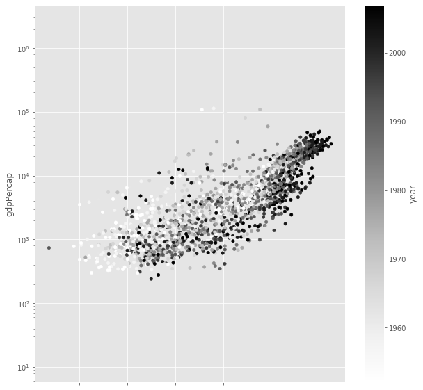

```python
data.plot(kind='scatter',y='gdpPercap',x='lifeExp',c='year',logy=True,figsize=(10,10))
plt.savefig('scatter.png')
```

```python
pwd
```

```
'/Users/swc/2020-01-13/Course Notes'
```

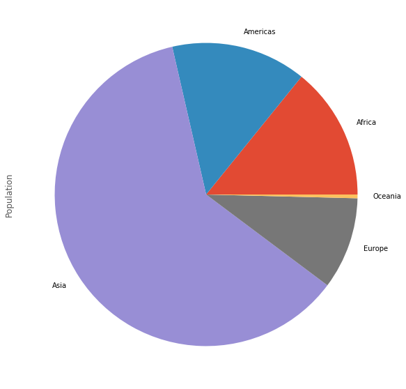

```python
_=data[data['year']==2002].groupby('continent').sum()['pop'].plot(kind='pie',figsize=(10,10),label='Population')
```

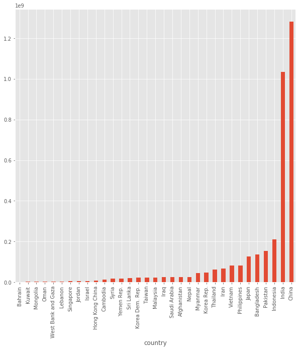

```python
_=data[(data['year']==2002) & (data['continent']=='Asia')].groupby('country').sum()['pop'].sort_values().plot(kind='bar',figsize=(10,10),)
```